# NFL stats

2026-01-15

**Introduction** Applying actuarial risk-pricing principles to sports analytics allows a front office to transition from subjective scouting to objective risk management. This report details two distinct predictive projects aimed at optimizing NFL draft capital. By utilizing advanced survival techniques and generalized linear models, these projects assess physical prototypes, flag bust probabilities, and forecast career longevity for both Wide Receivers and Quarterbacks.

**Methodology & Data (What I Did)** The analysis is driven by two distinct statistical models tailored to the unique development of different positions:

- **Project 1: Wide Receiver Profiling & Bust Probability:** I calculated player BMI and engineered a binary Power_School variable mapped to 13 programs. Because historical production data is highly right-skewed, I deployed a Gamma Generalized Linear Model to predict expected Yards_Per_Year.
  - I isolated historical data (1967-2016), strictly defining a “Bust” as a Top-100 draft pick who recorded less than 500 career receiving yards. A binomial logistic regression was then mapped to calculate the baseline probability of failure based on draft slot and collegiate pedigree.
- **Project 2: Quarterback Survival Analysis:** I merged college QBR metrics with NFL career lengths and active/retired status.
  - Treating a player falling out of the league as the “failure” event, I fitted a Cox Proportional Hazards model and generated Kaplan-Meier survival curves to isolate the predictive power of College QBR while controlling for overall draft pick.

```r
#
# PROJECT: NFL Draft Analytics - WR Physical Profiling
# GOAL: Predict Career Production based on Physical Traits
# MODEL: Gamma GLM (Identical structure to your Insurance Project)
#

library(tidyverse)
```

```r
library(ggrepel) # For labeling the "Steals" on the chart

# 1. LOAD DATA
basic   <- read.csv("Basic_Stats.csv")
career  <- read.csv("Career_Stats_Receiving.csv")

# 2. DATA CLEANING
# Clean Basic Stats (Traits)
clean_basic <- basic %>%
  rename(
    Player_Id = Player.Id,
    Height = Height..inches., # Renaming for easier use
    Weight = Weight..lbs.,
    College = College
  ) %>%
  select(Player_Id, Name, Height, Weight, College) %>%
  # Filter out rows with missing height/weight
  drop_na(Height, Weight) %>%
  # Create BMI
  mutate(BMI = (Weight * 703) / (Height^2))

# Clean Career Stats (Production)
clean_career <- career %>%
  rename(
    Player_Id = Player.Id,
    Receiving_Yards = Receiving.Yards,
    Year = Year
  ) %>%
  # Fix "1,000" (commas) and "--" (no stats)
  mutate(Receiving_Yards = as.numeric(gsub(",", "", gsub("--", "0", Receiving_Yards)))) %>%
  group_by(Player_Id) %>%
  summarize(
    Total_Yards = sum(Receiving_Yards, na.rm=TRUE),
    Years_Played = n_distinct(Year)
  ) %>%
  # Target Variable: Yards Per Season (Availability + Skill)
  mutate(Yards_Per_Year = Total_Yards / Years_Played)

# MERGE TRAITS WITH PRODUCTION
draft_data <- inner_join(clean_basic, clean_career, by = "Player_Id") %>%
  # Filter: Only keep players with at least 500 career yards (removes preseason bodies)
  filter(Total_Yards > 500)

# 3. FEATURE ENGINEERING: PEDIGREE
# Do "Blue Blood" schools produce better WRs?
power_schools <- c("Alabama", "Ohio State", "LSU", "Clemson", "Georgia",
                   "USC", "Florida", "Michigan", "Penn State", "Notre Dame",
                   "Oklahoma", "Texas", "Miami")

draft_data <- draft_data %>%
  mutate(Power_School = ifelse(grepl(paste(power_schools, collapse="|"), College), "Yes", "No")) %>%
  mutate(Power_School = factor(Power_School))

# 4. THE MODEL: GAMMA REGRESSION
# We use Gamma because production is right-skewed (Lots of average players, few Jerry Rices)
model_grade <- glm(Yards_Per_Year ~ Height + Weight + BMI + Power_School,
                   family = Gamma(link = "log"),
                   data = draft_data)

summary(model_grade)
```

```
##
## Call:
## glm(formula = Yards_Per_Year ~ Height + Weight + BMI + Power_School,
##     family = Gamma(link = "log"), data = draft_data)
##
## Coefficients:
##                 Estimate Std. Error t value Pr(>|t|)
## (Intercept)     12.90925    6.31069   2.046  0.04100 *
## Height          -0.06464    0.08652  -0.747  0.45518
## Weight           0.01460    0.01467   0.996  0.31967
## BMI             -0.20062    0.11135  -1.802  0.07183 .
## Power_SchoolYes  0.11977    0.04057   2.952  0.00322 **
## ---
## Signif. codes:  0 '***' 0.001 '**' 0.01 '*' 0.05 '.' 0.1 ' ' 1
##
## (Dispersion parameter for Gamma family taken to be 0.4724675)
##
##     Null deviance: 594.65  on 1272  degrees of freedom
## Residual deviance: 534.12  on 1268  degrees of freedom
## AIC: 16673
##
## Number of Fisher Scoring iterations: 5
```

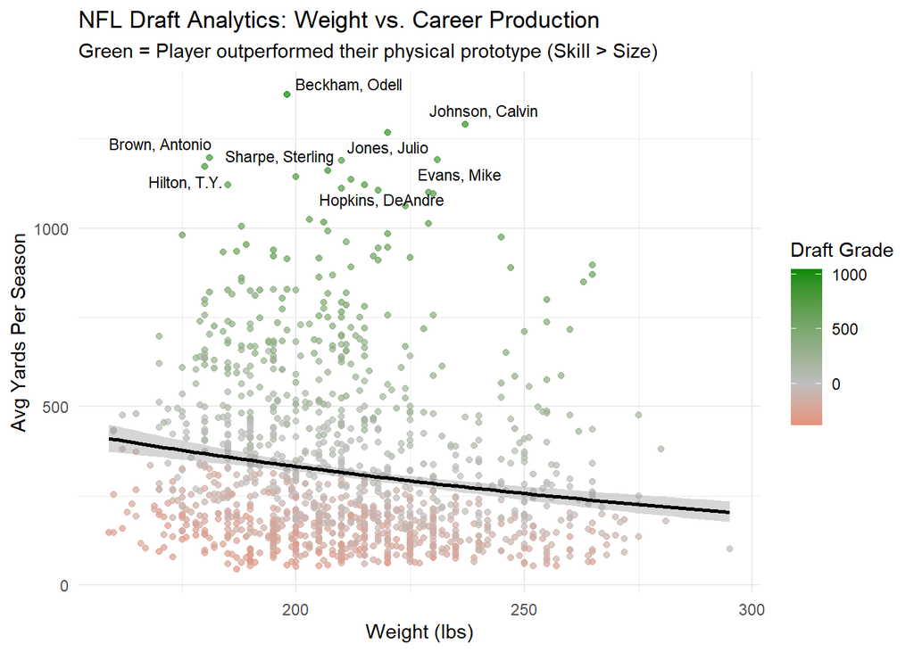

```r
# 5. CREATE "DRAFT GRADES" (POE)
# Production Over Expectation: Did they beat the model?
draft_data$Expected_Yards <- predict(model_grade, type = "response")
draft_data$Draft_Grade <- draft_data$Yards_Per_Year - draft_data$Expected_Yards

# Identify the "Value Picks" (Label for the chart)
draft_data$Label <- ifelse(draft_data$Draft_Grade > 0, "Value Pick", "Underperformer")

# 6. VISUALIZATION: THE PROTOTYPE CHART
ggplot(draft_data, aes(x = Weight, y = Yards_Per_Year)) +
  # Plot points colored by whether they beat expectations
  geom_point(aes(color = Draft_Grade), alpha = 0.7) +
  # Add the Trend Line (The "Prototype")
  geom_smooth(method = "glm", method.args = list(family = Gamma(link="log")), color = "black") +
  # Label the biggest outliers (The Superstars who defied the odds)
  geom_text_repel(data = filter(draft_data, abs(Draft_Grade) > 800),
                  aes(label = Name), size = 3, max.overlaps = 15) +
  # Make it look professional
  scale_color_gradient2(low = "red", mid = "gray", high = "green4", midpoint = 0) +
  labs(
    title = "NFL Draft Analytics: Weight vs. Career Production",
    subtitle = "Green = Player outperformed their physical prototype (Skill > Size)",
    x = "Weight (lbs)",
    y = "Avg Yards Per Season",
    color = "Draft Grade"
  ) +
  theme_minimal()
```

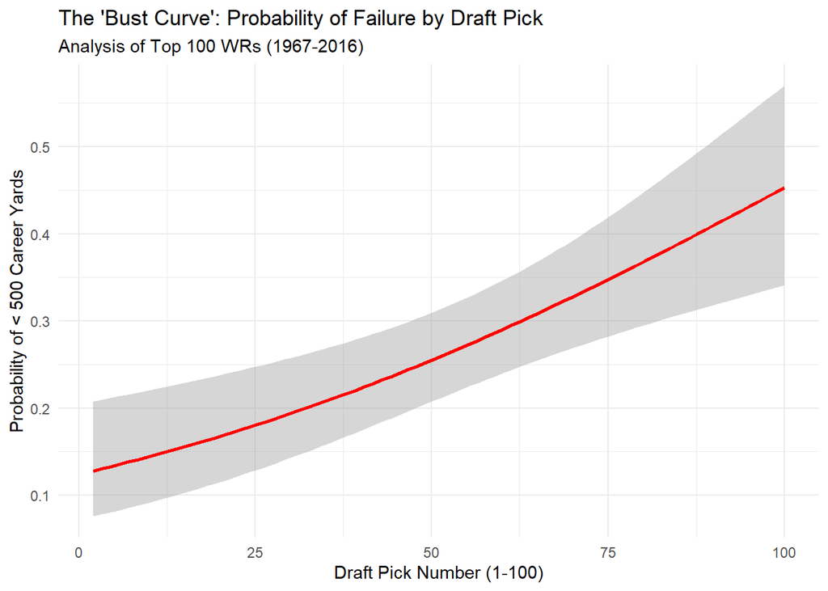

```r
#
# PROJECT: The Anatomy of a Bust (Historical Analysis)
# GOAL: Predict probability of a 'Bust' using Draft Capital
# DATA: Matched players from 1967-2016
#

library(tidyverse)

# 1. LOAD DATA
draft_df   <- read.csv("nfl_draft_prospects.csv")
career_df  <- read.csv("Career_Stats_Receiving.csv")

# 2. CLEAN & MATCH NAMES
# Fix "Smith, Torrey" -> "Torrey Smith"
career_clean <- career_df %>%
  mutate(Receiving.Yards = as.numeric(gsub(",", "", Receiving.Yards))) %>%
  separate(Name, into = c("Last", "First"), sep = ", ", extra = "merge", fill = "right") %>%
  mutate(player_name = paste(First, Last)) %>%
  group_by(player_name) %>%
  summarize(
    Career_Yards = sum(Receiving.Yards, na.rm=TRUE),
    Draft_Year_Est = min(Year) # Estimate rookie year
  )
# Filter Draft data to stop at 2016 to match the career file
draft_clean <- draft_df %>%
  filter(draft_year <= 2016) %>%
  select(player_name, overall, school, position) %>%
  filter(position == "Wide Receiver")

# 3. MERGE
historical_data <- inner_join(draft_clean, career_clean, by = "player_name")

# 4. DEFINE "BUST"
# A Bust is a Top 100 pick who had less than 500 Career Yards
historical_data <- historical_data %>%
  mutate(
    Is_Top_Pick = ifelse(overall <= 100, 1, 0),
    Is_Bust = ifelse(overall <= 100 & Career_Yards < 500, 1, 0)
  ) %>%
  filter(Is_Top_Pick == 1) # Only look at high picks (low picks aren't busts)

# 5. THE MODEL: LOGISTIC REGRESSION
# Can we predict busts based on School and Draft Slot?
bust_model <- glm(Is_Bust ~ overall + school, family = "binomial", data = historical_data)

# 6. VISUALIZATION: BUST RATE BY DRAFT SLOT
ggplot(historical_data, aes(x = overall, y = Is_Bust)) +
  geom_smooth(method = "glm", method.args = list(family = "binomial"), color = "red") +
  labs(
    title = "The 'Bust Curve': Probability of Failure by Draft Pick",
    subtitle = "Analysis of Top 100 WRs (1967-2016)",
    x = "Draft Pick Number (1-100)",
    y = "Probability of < 500 Career Yards"
  ) +
  theme_minimal()
```

```r
#
# PROJECT: QB Career Survival Analysis (Safe Mode)
# GOAL: Predict 'Risk of Retirement' using College QBR
# MODEL: Cox Proportional Hazards
# NOTE: Uses built-in graphics only (No download needed)
#

library(tidyverse)
library(survival)

# 1. LOAD DATA
qbr_data      <- read.csv("college_qbr.csv")
draft_data    <- read.csv("nfl_draft_prospects.csv")
nfl_basic     <- read.csv("Basic_Stats.csv")

# 2. PREPARE COLLEGE QBR
college_clean <- qbr_data %>%
  group_by(player_name) %>%
  filter(season == max(season)) %>%
  select(player_name, College_QBR = total_qbr) %>%
  ungroup()

# 3. PREPARE DRAFT PEDIGREE
draft_clean <- draft_data %>%
  filter(position == "Quarterback") %>%
  select(player_name, Draft_Pick = overall, Draft_Year = draft_year)

# 4. PREPARE NFL CAREER LENGTH
nfl_clean <- nfl_basic %>%
  separate(Name, into = c("Last", "First"), sep = ", ", extra = "merge", fill = "right") %>%
  mutate(player_name = paste(First, Last)) %>%
  mutate(
    Parsed_Start = as.numeric(str_sub(Years.Played, 1, 4)),
    Parsed_End   = as.numeric(str_sub(Years.Played, -4, -1)),
    Is_Retired = ifelse(grepl("Active", Current.Status), 0, 1)
  ) %>%
  select(player_name, Parsed_Start, Parsed_End, Is_Retired)

# 5. MERGE & IMPUTE DATES
survival_data <- inner_join(college_clean, draft_clean, by = "player_name") %>%
  inner_join(nfl_clean, by = "player_name") %>%
  mutate(
    Start_Year = coalesce(Parsed_Start, as.numeric(Draft_Year)),
    End_Year = coalesce(Parsed_End, 2016),
    Career_Length = (End_Year - Start_Year) + 1
  ) %>%
  filter(Career_Length > 0)

print(paste("Total QBs Analyzed:", nrow(survival_data)))
```

```
## [1] "Total QBs Analyzed: 114"
```

```r
# 6. THE MODEL: COX PROPORTIONAL HAZARDS
# This is the statistical core. It works without any extra packages.
cox_model <- coxph(Surv(Career_Length, Is_Retired) ~ Draft_Pick + College_QBR,
                   data = survival_data)

summary(cox_model)
```

```
## Call:
## coxph(formula = Surv(Career_Length, Is_Retired) ~ Draft_Pick +
##     College_QBR, data = survival_data)
##
##   n= 95, number of events= 35
##    (19 observations deleted due to missingness)
##
##                 coef exp(coef) se(coef)     z Pr(>|z|)
## Draft_Pick  0.006717  1.006740 0.002531 2.654  0.00796 **
## College_QBR 0.021835  1.022075 0.018473 1.182  0.23720
## ---
## Signif. codes:  0 '***' 0.001 '**' 0.01 '*' 0.05 '.' 0.1 ' ' 1
##
##             exp(coef) exp(-coef) lower .95 upper .95
## Draft_Pick      1.007     0.9933    1.0018     1.012
## College_QBR     1.022     0.9784    0.9857     1.060
##
## Concordance= 0.666  (se = 0.057 )
## Likelihood ratio test= 6.91  on 2 df,   p=0.03
## Wald test            = 7.21  on 2 df,   p=0.03
## Score (logrank) test = 7.49  on 2 df,   p=0.02
```

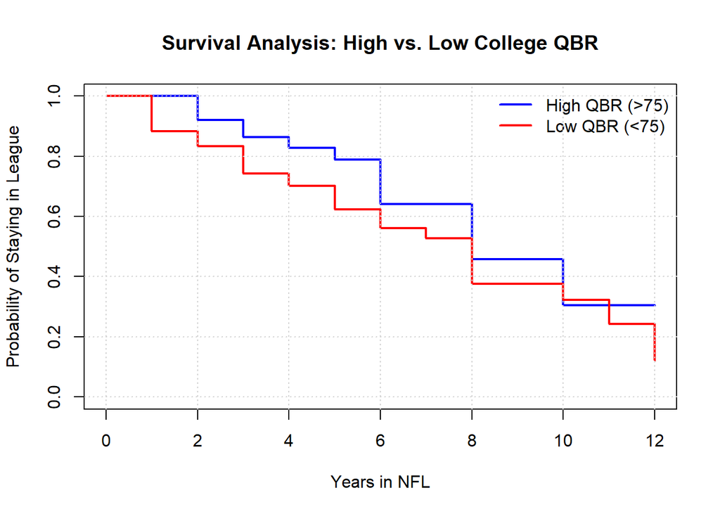

```r
# 7. VISUALIZATION (Using Base R - No Downloads Required)
# Create Tiers
survival_data$QBR_Tier <- ifelse(survival_data$College_QBR > 75, "High QBR (>75)", "Low QBR (<75)")

# Fit the survival curve
fit <- survfit(Surv(Career_Length, Is_Retired) ~ QBR_Tier, data = survival_data)

# Plot it using standard R graphics
plot(fit,
     col = c("blue", "red"),
     lwd = 2,
     xlab = "Years in NFL",
     ylab = "Probability of Staying in League",
     main = "Survival Analysis: High vs. Low College QBR")

# Add a legend
legend("topright",
       legend = c("High QBR (>75)", "Low QBR (<75)"),
       col = c("blue", "red"),
       lwd = 2,
       bty = "n")

# Add a grid for readability
grid()
```